# Gun Violence Analysis

Examining Relationships Between Firearm Mortality and Social Factors

# 1 Introduction

In this document, we analyze:

1. The relationship between gun law strength and firearm mortality
2. Factors associated with firearm mortality rates
3. The impact of specific gun policies on mortality outcomes

Our analysis draws on state-level data from multiple sources, including firearm mortality statistics, gun ownership rates, and policy information.

# 2 Relationship Between Gun Law Strength and Firearm Mortality

One of the key questions in gun violence research is whether stronger gun laws are associated with lower firearm mortality rates. The following visualization examines this relationship.

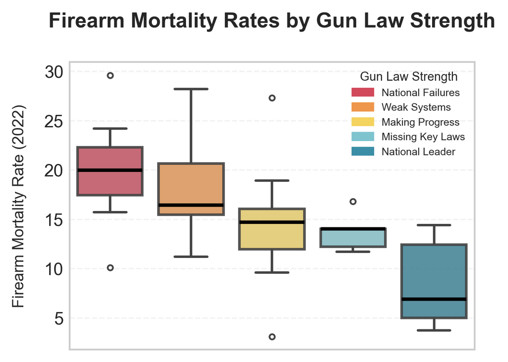

This boxplot reveals a clear pattern: states with stronger gun laws (“National Leader” and “Missing Key Laws” categories) generally have lower firearm mortality rates compared to states categorized as “National Failures” or those with “Weak Systems.” The median mortality rate decreases as gun law strength increases, suggesting that comprehensive gun legislation may be associated with reduced firearm deaths.

## 2.1 Child Firearm Mortality

Children are particularly vulnerable to firearm violence. Let’s examine whether the overall firearm mortality rate in a state is associated with child-specific mortality rates.

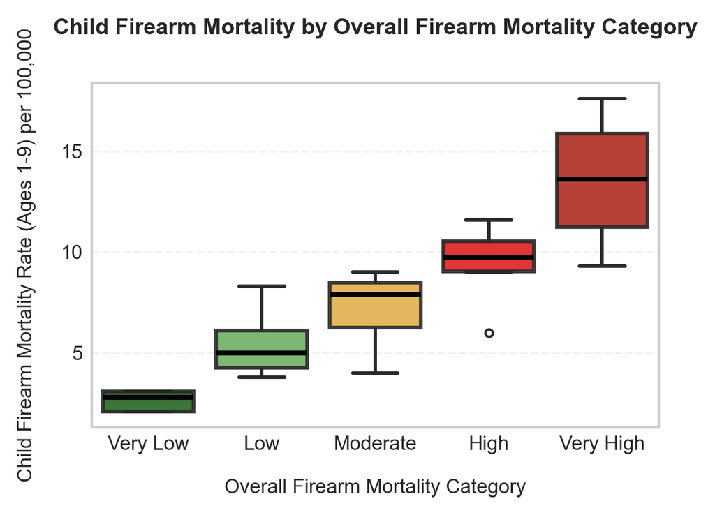

The plot demonstrates that children in states with higher overall firearm mortality rates also face higher risks of firearm-related deaths. This suggests that factors contributing to general firearm violence also affect child safety, potentially including access to firearms, storage practices, and broader gun safety culture.

## 2.2 Gun Ownership Rates

A critical factor to examine is the relationship between gun ownership rates and firearm mortality.

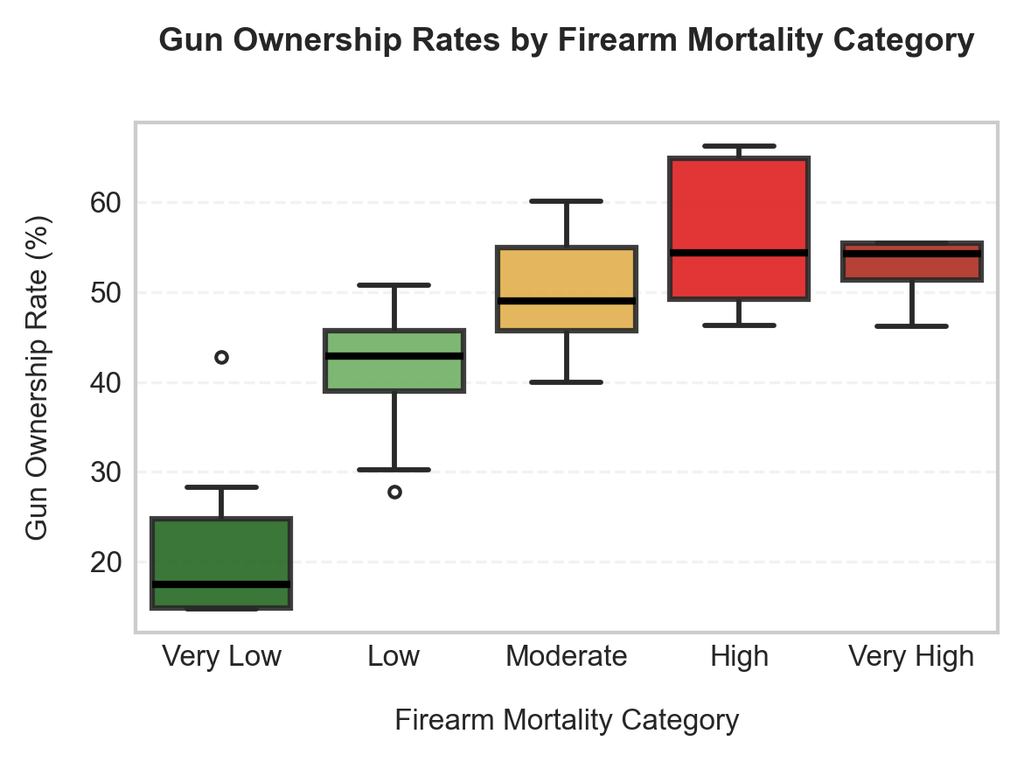

The visualization shows a clear positive association between gun ownership rates and firearm mortality. States categorized as having “Very High” or “High” firearm mortality typically have substantially higher gun ownership rates than states with “Very Low” mortality rates. This suggests that the prevalence of firearms in a state may be a significant factor in firearm-related deaths.

# 3 Social and Economic Factors Related to Firearm Mortality

## 3.1 Women’s Labor Force Participation

Research suggests that women’s economic empowerment may be correlated with various social outcomes. Let’s examine the relationship between women’s labor force participation and firearm mortality rates.

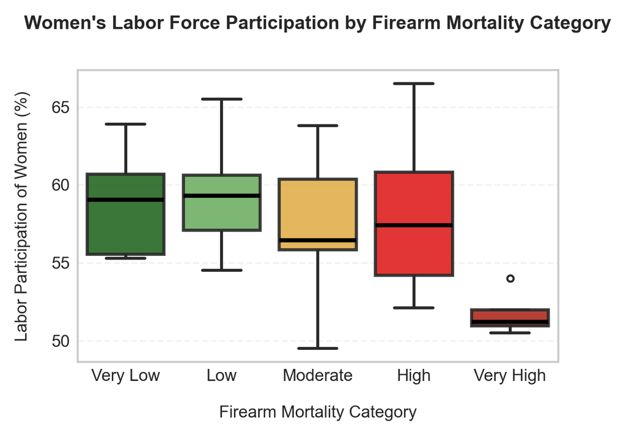

The data indicates that states with lower firearm mortality rates tend to have higher women’s labor force participation rates compared to states with higher mortality rates. This could reflect broader socioeconomic factors or cultural differences between states.

## 3.2 Alcohol-Related Deaths

Substance use is often examined alongside violence. Here, we look at whether alcohol-related deaths correlate with firearm mortality.

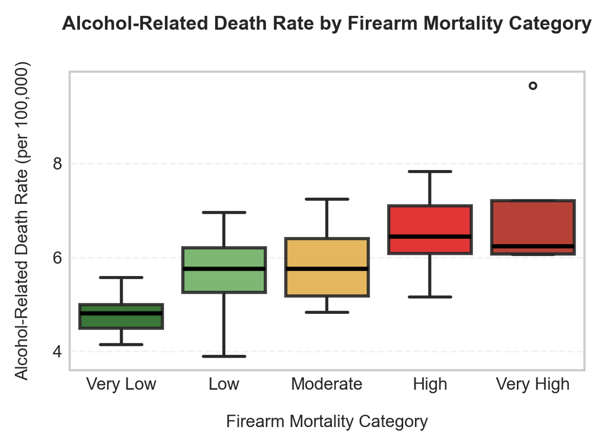

There appears to be a relationship between alcohol-related deaths and firearm mortality rates, with states having higher firearm mortality also showing higher alcohol-related death rates. This may reflect broader public health challenges or risk factors that span multiple domains.

# 4 Specific Gun Policies and Their Relationship to Firearm Mortality

Now we’ll examine how specific gun policies correlate with firearm mortality rates. For this analysis, we’ll create stacked bar charts that show the distribution of mortality categories for states with and without particular policies.

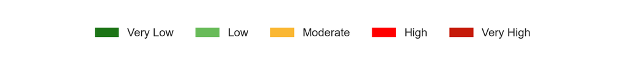

## 4.1 Age Requirements for Firearm Purchase

Age requirements restrict gun purchases for individuals below a specified age. Let’s examine whether states with these policies show different mortality patterns.

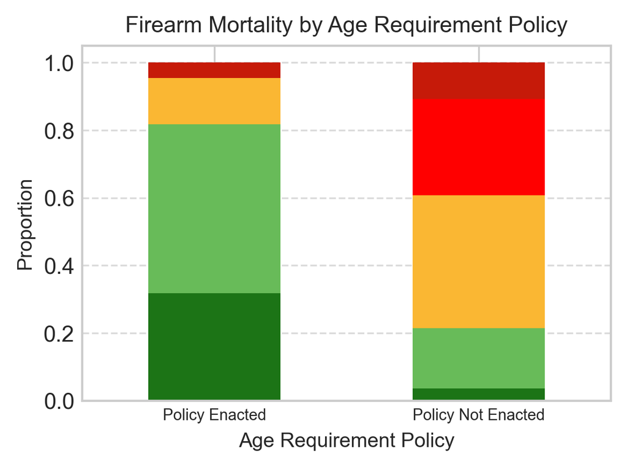

States that have enacted age requirement policies for firearm purchases show a notably different distribution of mortality rates compared to states without such policies. The former have a higher proportion of states in the “Very Low” and “Low” mortality categories, suggesting that age requirements may be associated with lower firearm mortality rates.

## 4.2 Gun Removal Programs

Gun removal programs, often known as “red flag laws” or Extreme Risk Protection Orders, allow for the temporary removal of firearms from individuals deemed to be at high risk of harming themselves or others.

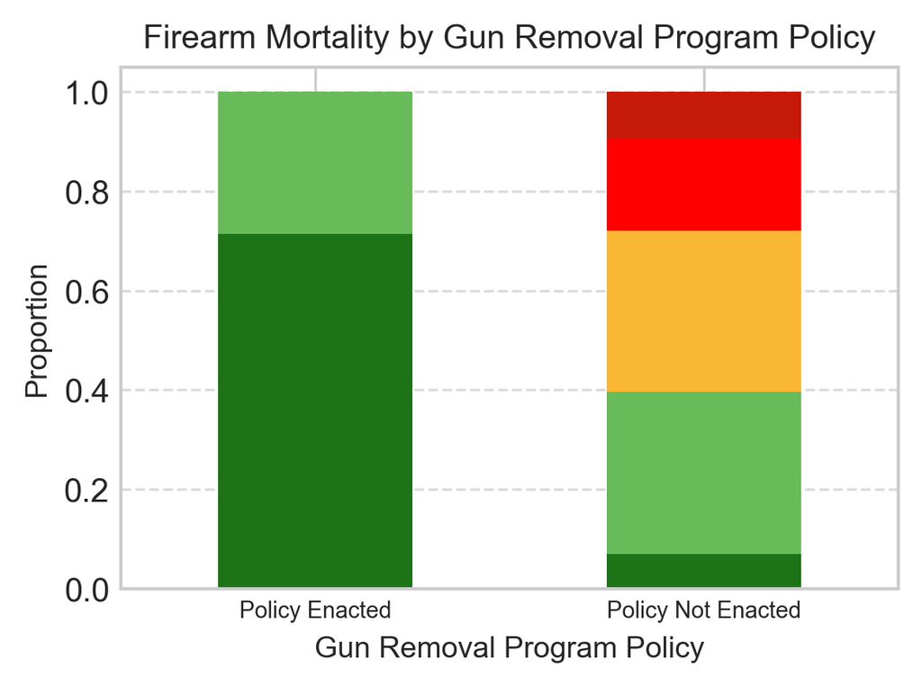

The data reveals that states with gun removal programs have a substantially higher proportion in the “Very Low” and “Low” mortality categories compared to states without such programs. This suggests that policies enabling the temporary removal of firearms from high-risk individuals might be effective in reducing firearm deaths.

## 4.3 High-Capacity Magazine Restrictions

High-capacity magazines allow firearms to fire many rounds without reloading. Restrictions on these devices are meant to reduce casualties in mass shooting events.

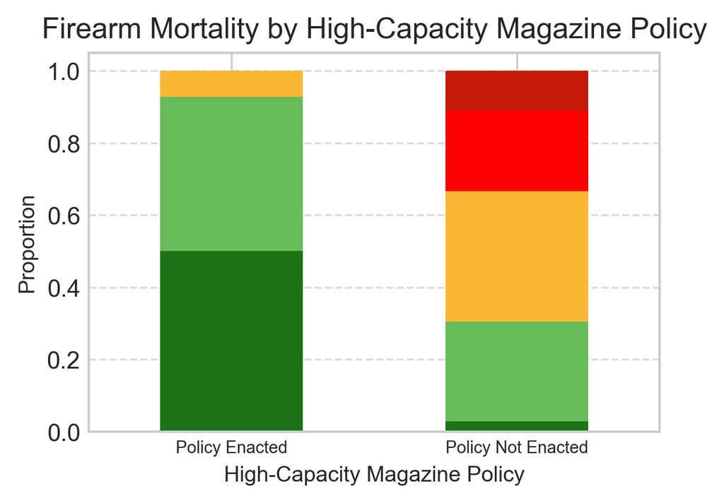

States that have enacted high-capacity magazine prohibitions show a markedly different distribution of mortality rates, with a higher percentage falling into the “Very Low” category compared to states without such restrictions. This suggests that limiting high-capacity magazines may be associated with lower overall firearm mortality rates.

## 4.4 Assault Weapons Prohibitions

Assault weapons bans restrict civilian access to certain semi-automatic firearms with specific features.

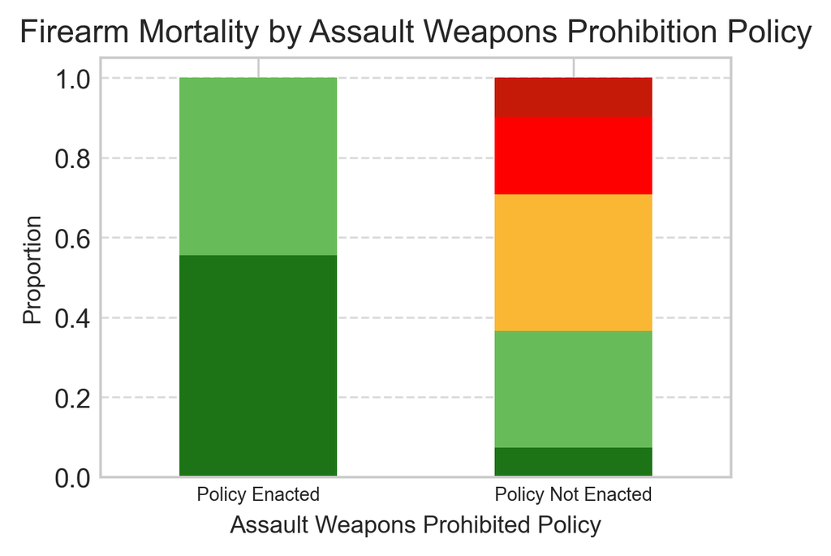

Similar to high-capacity magazine restrictions, states with assault weapons prohibitions have a higher proportion in the “Very Low” mortality category compared to states without such bans. This relationship warrants further investigation to understand the specific mechanisms by which these policies might reduce firearm deaths.

## 4.5 Secure Storage and Child Access Laws

Safe storage laws require gun owners to store firearms securely to prevent unauthorized access, especially by children.

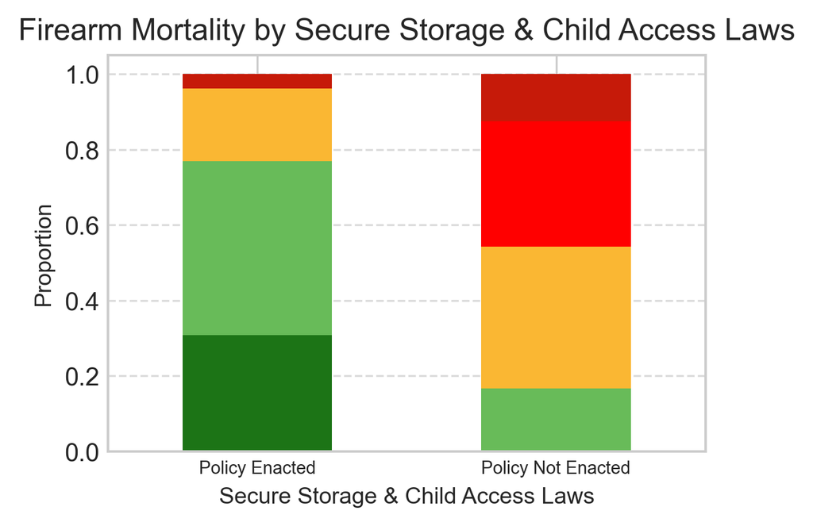

States with secure storage and child access laws demonstrate a notably different mortality profile, with a higher percentage in the “Very Low” and “Low” categories. These laws, which aim to prevent unauthorized access to firearms (particularly by children), appear to be associated with reduced firearm mortality rates.

## 4.6 Background Checks and Purchase Permits

Background check requirements aim to prevent prohibited individuals from purchasing firearms by verifying their eligibility.

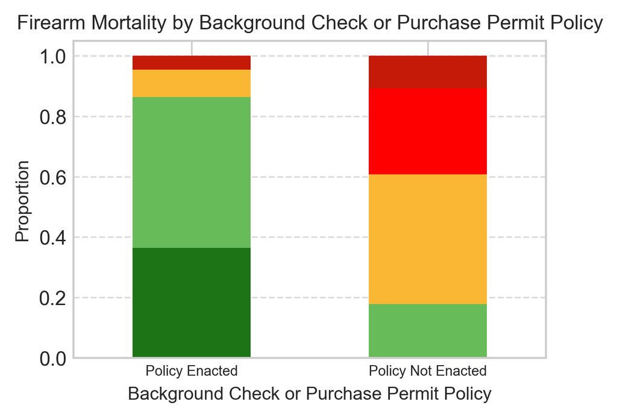

The data reveals that states requiring background checks or purchase permits for firearms have a higher proportion of states in the “Very Low” and “Low” mortality categories. This suggests that policies designed to screen potential gun purchasers may be effective in reducing firearm-related deaths.

# 5 Conclusion

Our analysis reveals several important patterns in the relationship between firearm policies, social factors, and mortality rates:

1. **Gun Law Strength**: States with stronger gun laws generally have lower firearm mortality rates, suggesting that comprehensive gun legislation may effectively reduce gun violence.
2. **Social Factors**: Several social and economic factors correlate with firearm mortality:
   - Women’s labor force participation is higher in states with lower firearm mortality
   - Gun ownership rates are substantially higher in states with higher mortality rates
   - Both children’s firearm mortality and alcohol-related deaths follow similar patterns to overall firearm mortality
3. **Specific Policies**: Multiple gun policies appear to be associated with lower firearm mortality rates:
   - Age requirements for firearm purchases
   - Gun removal programs for high-risk individuals
   - Restrictions on high-capacity magazines and assault weapons
   - Secure storage requirements and child access prevention laws
   - Background checks and purchase permit systems

These findings suggest that a multifaceted approach to reducing gun violence could be effective, combining policy interventions with broader social and economic initiatives. However, it’s important to note that correlation does not imply causation, and further research is needed to establish causal relationships and understand the specific mechanisms by which these factors influence firearm mortality.

Future research should consider longitudinal studies examining changes in mortality rates following policy implementations, as well as more detailed analyses of the interactions between different factors. Additionally, qualitative research could provide insights into how these policies are implemented and experienced on the ground.